# HW #5 Tips

# Load the data

In this example, we loaad the Fed Papers in Corpus format. Its always a good idea to peak at the data to be sure it has loaded correctly!!

```r
#Load Fed Papers Corpus
FedPapersCorpus <- Corpus(DirSource("FedPapersCorpus"))
(numberFedPapers<-length(FedPapersCorpus))
```

```
## [1] 85
```

```r
## The following will show you that you read in all the documents
(summary(FedPapersCorpus))
```

```
##                     Length Class             Mode
## dispt_fed_49.txt    2      PlainTextDocument list
## dispt_fed_50.txt    2      PlainTextDocument list
## dispt_fed_51.txt    2      PlainTextDocument list
## dispt_fed_52.txt    2      PlainTextDocument list
## dispt_fed_53.txt    2      PlainTextDocument list
## dispt_fed_54.txt    2      PlainTextDocument list
## dispt_fed_55.txt    2      PlainTextDocument list
## dispt_fed_56.txt    2      PlainTextDocument list
## dispt_fed_57.txt    2      PlainTextDocument list
## dispt_fed_62.txt    2      PlainTextDocument list
## dispt_fed_63.txt    2      PlainTextDocument list
## Hamilton_fed_1.txt  2      PlainTextDocument list
## Hamilton_fed_11.txt 2      PlainTextDocument list
## Hamilton_fed_12.txt 2      PlainTextDocument list
## Hamilton_fed_13.txt 2      PlainTextDocument list
## Hamilton_fed_15.txt 2      PlainTextDocument list
## Hamilton_fed_16.txt 2      PlainTextDocument list
## Hamilton_fed_17.txt 2      PlainTextDocument list
## Hamilton_fed_21.txt 2      PlainTextDocument list
## Hamilton_fed_22.txt 2      PlainTextDocument list
## Hamilton_fed_23.txt 2      PlainTextDocument list
## Hamilton_fed_24.txt 2      PlainTextDocument list
## Hamilton_fed_25.txt 2      PlainTextDocument list
## Hamilton_fed_26.txt 2      PlainTextDocument list
## Hamilton_fed_27.txt 2      PlainTextDocument list
## Hamilton_fed_28.txt 2      PlainTextDocument list
## Hamilton_fed_29.txt 2      PlainTextDocument list
## Hamilton_fed_30.txt 2      PlainTextDocument list
## Hamilton_fed_31.txt 2      PlainTextDocument list
## Hamilton_fed_32.txt 2      PlainTextDocument list
## Hamilton_fed_33.txt 2      PlainTextDocument list
## Hamilton_fed_34.txt 2      PlainTextDocument list
## Hamilton_fed_35.txt 2      PlainTextDocument list
## Hamilton_fed_36.txt 2      PlainTextDocument list
## Hamilton_fed_59.txt 2      PlainTextDocument list
## Hamilton_fed_6.txt  2      PlainTextDocument list
## Hamilton_fed_60.txt 2      PlainTextDocument list
## Hamilton_fed_61.txt 2      PlainTextDocument list
## Hamilton_fed_65.txt 2      PlainTextDocument list
```

[output cut: 31 more lines]

```
## Madison_fed_10.txt  2      PlainTextDocument list
## Madison_fed_14.txt  2      PlainTextDocument list
## Madison_fed_37.txt  2      PlainTextDocument list
## Madison_fed_38.txt  2      PlainTextDocument list
## Madison_fed_39.txt  2      PlainTextDocument list
## Madison_fed_40.txt  2      PlainTextDocument list
## Madison_fed_41.txt  2      PlainTextDocument list
## Madison_fed_42.txt  2      PlainTextDocument list
## Madison_fed_43.txt  2      PlainTextDocument list
## Madison_fed_44.txt  2      PlainTextDocument list
## Madison_fed_45.txt  2      PlainTextDocument list
## Madison_fed_46.txt  2      PlainTextDocument list
## Madison_fed_47.txt  2      PlainTextDocument list
## Madison_fed_48.txt  2      PlainTextDocument list
## Madison_fed_58.txt  2      PlainTextDocument list
```

```r
(meta(FedPapersCorpus[[1]]))
```

```
##   author       : character(0)
##   datetimestamp: 2019-09-16 17:25:07
##   description  : character(0)
##   heading      : character(0)
##   id           : dispt_fed_49.txt
##   language     : en
##   origin       : character(0)
```

```r
(meta(FedPapersCorpus[[1]],5))
```

```
## [1] "dispt_fed_49.txt"
```

# Cleaning and Preprocessing

Choosing some good stop words can really go a long way to improve modeling results. There are also many other parameters one can tweak and tune using the DocumentTermMatrix function. See many below.

```r
#Data Preparation and Transformation on Fed Papers
##Remove punctuation,numbers, and space
(getTransformations())
```

```
## [1] "removeNumbers"     "removePunctuation" "removeWords"
## [4] "stemDocument"      "stripWhitespace"
```

```r
(nFedPapersCorpus<-length(FedPapersCorpus))
```

```
## [1] 85
```

```r
##Ignore extremely rare words i.e. terms that appear in less then 1% of the documents
(minTermFreq <-30)
```

```
## [1] 30
```

```r
##Ignore overly common words i.e. terms that appear in more than 50% of the documents
(maxTermFreq <-1000)
```

```
## [1] 1000
```

```r
(MyStopwords <- c("will","one","two", "may","less","publius","Madison","Alexand", "Alexander", "James", "Hamilton","Jay", "well","might","without","small", "single", "several", "but", "very", "can", "must", "also", "any", "and", "are", "however", "into", "almost", "can","for", "add", "Author" ))
```

```
##  [1] "will"      "one"       "two"       "may"       "less"
##  [6] "publius"   "Madison"   "Alexand"   "Alexander" "James"
## [11] "Hamilton"  "Jay"       "well"      "might"     "without"
## [16] "small"     "single"    "several"   "but"       "very"
## [21] "can"       "must"      "also"      "any"       "and"
## [26] "are"       "however"   "into"      "almost"    "can"
## [31] "for"       "add"       "Author"
```

```r
(STOPS <-stopwords('english'))
```

```
##   [1] "i"          "me"         "my"         "myself"     "we"
##   [6] "our"        "ours"       "ourselves"  "you"        "your"
##  [11] "yours"      "yourself"   "yourselves" "he"         "him"
##  [16] "his"        "himself"    "she"        "her"        "hers"
##  [21] "herself"    "it"         "its"        "itself"     "they"
##  [26] "them"       "their"      "theirs"     "themselves" "what"
##  [31] "which"      "who"        "whom"       "this"       "that"
##  [36] "these"      "those"      "am"         "is"         "are"
##  [41] "was"        "were"       "be"         "been"       "being"
##  [46] "have"       "has"        "had"        "having"     "do"
##  [51] "does"       "did"        "doing"      "would"      "should"
##  [56] "could"      "ought"      "i'm"        "you're"     "he's"
##  [61] "she's"      "it's"       "we're"      "they're"    "i've"
##  [66] "you've"     "we've"      "they've"    "i'd"        "you'd"
##  [71] "he'd"       "she'd"      "we'd"       "they'd"     "i'll"
```

[output cut: 20 more lines]

```r
Papers_DTM <- DocumentTermMatrix(FedPapersCorpus,
                         control = list(
                           stopwords = TRUE,
                           wordLengths=c(3, 15),
                           removePunctuation = T,
                           removeNumbers = T,
                           tolower=T,
                           stemming = T,
                           remove_separators = T,
                           stopwords = MyStopwords,
                           removeWords=STOPS,
                           removeWords=MyStopwords,
                           bounds = list(global = c(minTermFreq, maxTermFreq))
                         ))

##inspect FedPapers Document Term Matrix (DTM)
DTM <- as.matrix(Papers_DTM)
#(DTM[1:11,1:10])
```

# Vectorization

Vectorizing words is often done by encoding frequency information. Below we take a peak at the frequency of the words. Next some normalization techniques are tried. Which works best … ?? Try many and assess the results!!!

```r
##Look at word freuquncies
WordFreq <- colSums(as.matrix(Papers_DTM))
(head(WordFreq))
```

```
##       abl   absolut    accord       act     addit administr
##        74        63        71       139        61        90
```

```r
(length(WordFreq))
```

```
## [1] 427
```

```r
ord <- order(WordFreq)
(WordFreq[head(ord)])
```

```
##    jame   expos furnish    word  unless   bound
##      30      34      36      36      37      38
```

```r
(WordFreq[tail(ord)])
```

```
## constitut       may     power    govern      will     state
##       686       811       937      1040      1263      1662
```

```r
## Row Sums per Fed Papers
(Row_Sum_Per_doc <- rowSums((as.matrix(Papers_DTM))))
```

```
##    dispt_fed_49.txt    dispt_fed_50.txt    dispt_fed_51.txt
##                 514                 338                 658
##    dispt_fed_52.txt    dispt_fed_53.txt    dispt_fed_54.txt
##                 565                 701                 582
##    dispt_fed_55.txt    dispt_fed_56.txt    dispt_fed_57.txt
##                 647                 553                 613
##    dispt_fed_62.txt    dispt_fed_63.txt  Hamilton_fed_1.txt
##                 698                 955                 483
## Hamilton_fed_11.txt Hamilton_fed_12.txt Hamilton_fed_13.txt
##                 564                 539                 318
## Hamilton_fed_15.txt Hamilton_fed_16.txt Hamilton_fed_17.txt
##                 815                 558                 477
## Hamilton_fed_21.txt Hamilton_fed_22.txt Hamilton_fed_23.txt
##                 537                 985                 560
## Hamilton_fed_24.txt Hamilton_fed_25.txt Hamilton_fed_26.txt
##                 519                 570                 670
## Hamilton_fed_27.txt Hamilton_fed_28.txt Hamilton_fed_29.txt
##                 466                 507                 541
## Hamilton_fed_30.txt Hamilton_fed_31.txt Hamilton_fed_32.txt
##                 585                 510                 442
## Hamilton_fed_33.txt Hamilton_fed_34.txt Hamilton_fed_35.txt
##                 522                 618                 663
## Hamilton_fed_36.txt Hamilton_fed_59.txt  Hamilton_fed_6.txt
##                 824                 603                 461
## Hamilton_fed_60.txt Hamilton_fed_61.txt Hamilton_fed_65.txt
##                 657                 444                 560
## Hamilton_fed_66.txt Hamilton_fed_67.txt Hamilton_fed_68.txt
##                 646                 443                 449
## Hamilton_fed_69.txt  Hamilton_fed_7.txt Hamilton_fed_70.txt
##                 811                 580                 852
## Hamilton_fed_71.txt Hamilton_fed_72.txt Hamilton_fed_73.txt
##                 473                 539                 696
## Hamilton_fed_74.txt Hamilton_fed_75.txt Hamilton_fed_76.txt
##                 282                 597                 594
## Hamilton_fed_77.txt Hamilton_fed_78.txt Hamilton_fed_79.txt
##                 586                 891                 301
##  Hamilton_fed_8.txt Hamilton_fed_80.txt Hamilton_fed_81.txt
##                 533                 771                1188
## Hamilton_fed_82.txt Hamilton_fed_83.txt Hamilton_fed_84.txt
##                 504                1598                1255
## Hamilton_fed_85.txt  Hamilton_fed_9.txt       HM_fed_18.txt
##                 773                 520                 443
##       HM_fed_19.txt       HM_fed_20.txt       Jay_fed_2.txt
##                 466                 395                 477
##       Jay_fed_3.txt       Jay_fed_4.txt       Jay_fed_5.txt
##                 515                 463                 401
##      Jay_fed_64.txt  Madison_fed_10.txt  Madison_fed_14.txt
##                 692                 884                 553
##  Madison_fed_37.txt  Madison_fed_38.txt  Madison_fed_39.txt
##                 723                 874                 859
##  Madison_fed_40.txt  Madison_fed_41.txt  Madison_fed_42.txt
##                 857                1020                 800
##  Madison_fed_43.txt  Madison_fed_44.txt  Madison_fed_45.txt
##                 993                 927                 724
##  Madison_fed_46.txt  Madison_fed_47.txt  Madison_fed_48.txt
##                 832                 925                 565
##  Madison_fed_58.txt
##                 655
```

```r
## Create a normalized version of Papers_DTM
Papers_M <- as.matrix(Papers_DTM)
Papers_M_N1 <- apply(Papers_M, 1, function(i) round(i/sum(i),3))
Papers_Matrix_Norm <- t(Papers_M_N1)


## Convert to matrix and view
Papers_dtm_matrix = as.matrix(Papers_DTM)
#str(Papers_dtm_matrix)
#(Papers_dtm_matrix[c(1:11),c(2:10)])
```

# Label the Data

Below we label the data, prepare for modeling, and create some wordclouds for fun.

```r
## Also convert to DF
Papers_DF <- as.data.frame(as.matrix(Papers_Matrix_Norm))
Papers_DF1<- Papers_DF%>%add_rownames()
names(Papers_DF1)[1]<-"Author"
Papers_DF1[1:11,1]="dispt"
Papers_DF1[12:62,1]="hamil"
Papers_DF1[63:77,1]="madis"
head(Papers_DF1)
```

```
## # A tibble: 6 x 428
##   Author   abl absolut accord   act addit administr admit adopt advantag
##   <chr>  <dbl>   <dbl>  <dbl> <dbl> <dbl>     <dbl> <dbl> <dbl>    <dbl>
## 1 dispt  0.004   0      0     0     0         0.002 0.002 0        0.008
## 2 dispt  0       0.006  0     0     0         0.006 0     0        0.003
## 3 dispt  0.002   0.003  0     0     0.002     0.002 0.005 0        0
## 4 dispt  0.002   0.002  0     0.002 0.002     0     0     0.002    0.004
## 5 dispt  0       0      0.001 0.003 0         0     0.001 0        0.003
## 6 dispt  0       0      0.003 0.002 0         0     0.009 0.002    0.007
## # ... with 418 more variables: affair <dbl>, affect <dbl>, afford <dbl>,
## #   alexand <dbl>, almost <dbl>, alon <dbl>, alreadi <dbl>, also <dbl>,
## #   alway <dbl>, america <dbl>, among <dbl>, amount <dbl>, anoth <dbl>,
## #   answer <dbl>, appear <dbl>, appli <dbl>, applic <dbl>, appoint <dbl>,
## #   apprehens <dbl>, argument <dbl>, aris <dbl>, articl <dbl>,
## #   assembl <dbl>, attempt <dbl>, attend <dbl>, attent <dbl>,
## #   author <dbl>, avoid <dbl>, becom <dbl>, best <dbl>, better <dbl>,
## #   bodi <dbl>, bound <dbl>, branch <dbl>, britain <dbl>, calcul <dbl>,
## #   call <dbl>, can <dbl>, capac <dbl>, care <dbl>, carri <dbl>,
## #   case <dbl>, caus <dbl>, certain <dbl>, chang <dbl>, charact <dbl>,
## #   circumst <dbl>, citizen <dbl>, civil <dbl>, class <dbl>, clear <dbl>,
## #   collect <dbl>, combin <dbl>, commit <dbl>, common <dbl>,
## #   communiti <dbl>, complet <dbl>, compos <dbl>, concern <dbl>,
## #   conclus <dbl>, conduct <dbl>, confeder <dbl>, confederaci <dbl>,
## #   confid <dbl>, confin <dbl>, congress <dbl>, connect <dbl>,
## #   consequ <dbl>, consid <dbl>, consider <dbl>, consist <dbl>,
## #   constitu <dbl>, constitut <dbl>, contend <dbl>, continu <dbl>,
## #   contrari <dbl>, control <dbl>, convent <dbl>, council <dbl>,
## #   countri <dbl>, cours <dbl>, danger <dbl>, decid <dbl>, decis <dbl>,
## #   declar <dbl>, defect <dbl>, defens <dbl>, degre <dbl>, deliber <dbl>,
## #   depart <dbl>, depend <dbl>, deriv <dbl>, descript <dbl>, design <dbl>,
## #   desir <dbl>, determin <dbl>, differ <dbl>, difficulti <dbl>,
## #   direct <dbl>, dispos <dbl>, ...
```

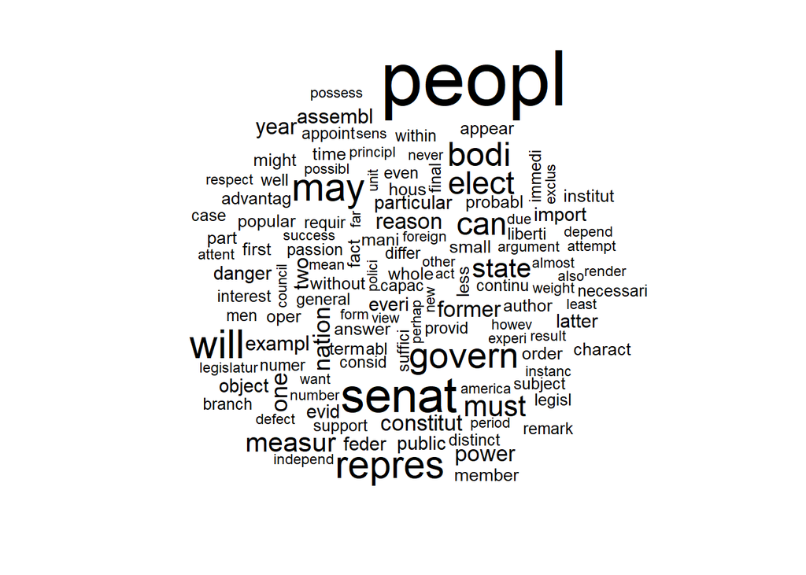

```r
#Wordcloud Visualization Hamilton, Madison and Disputed Papers
DisputedPapersWC<- wordcloud(colnames(Papers_dtm_matrix), Papers_dtm_matrix[11,])
```

```r
(head(sort(as.matrix(Papers_dtm_matrix)[11,], decreasing = TRUE), n=50))
```

```
##      peopl      senat       will        may     repres     govern
##         42         24         19         18         18         16
##       bodi        can      elect       must     measur      state
##         15         14         14         12         11         11
##     nation        one  constitut     former      power     reason
##          9          9          8          8          8          8
##       year    assembl     exampl        two     danger      everi
##          8          7          7          7          6          6
##       evid      feder     import     latter     object particular
##          6          6          6          6          6          6
##     public   advantag     answer     appear     author    charact
##          6          5          5          5          5          5
##       fact      first       hous   institut       less       mani
##          5          5          5          5          5          5
##     member      might       oper      order       part    popular
##          5          5          5          5          5          5
##    probabl      small
##          5          5
```

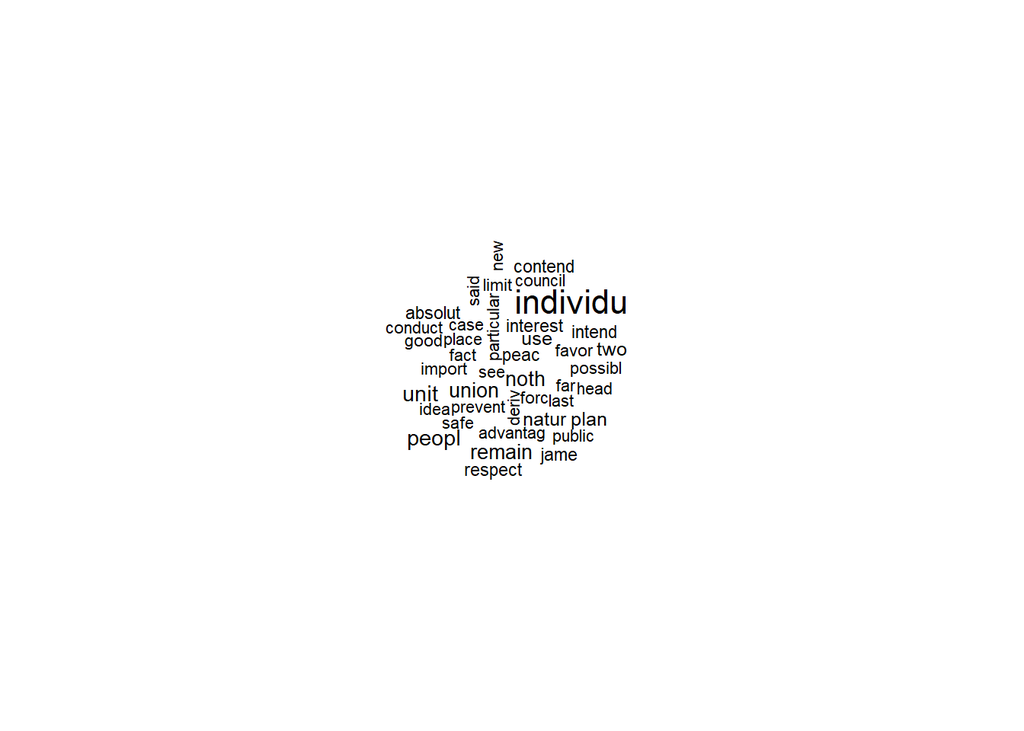

```r
HamiltonPapersWC <-wordcloud(colnames(Papers_dtm_matrix),Papers_dtm_matrix[12:62,])
```

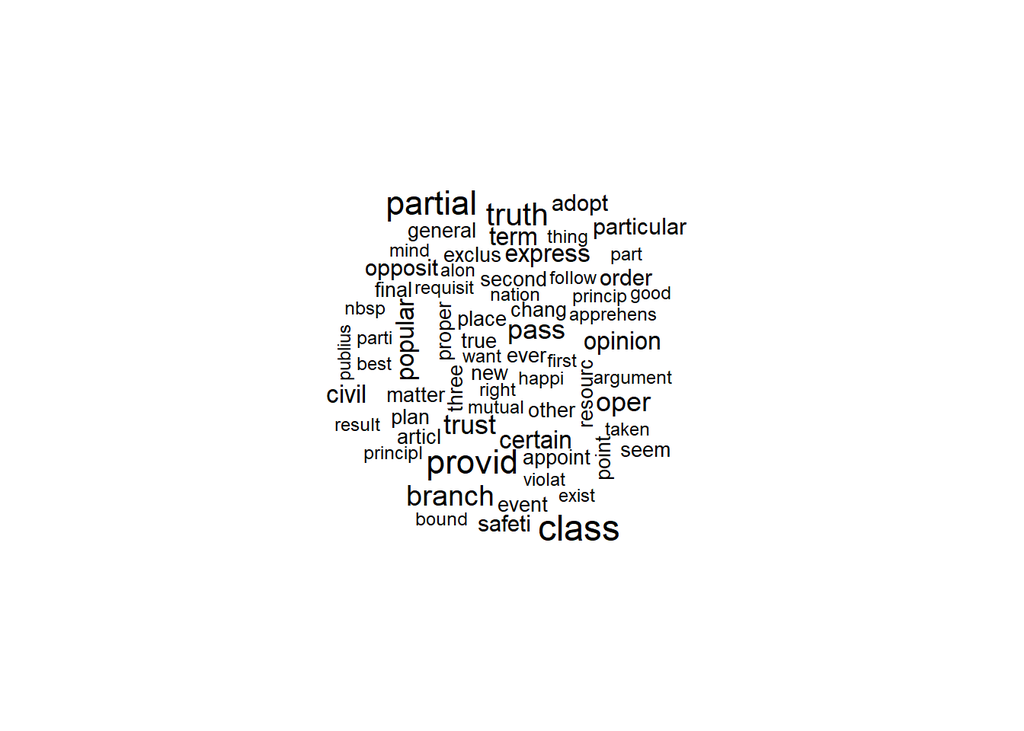

```r
MadisonPapersHW <-wordcloud(colnames(Papers_dtm_matrix), Papers_dtm_matrix[63:77,])
```

# Experimental Design

Now that the data is labeled, its time to design an experiment. Below we randomly select a train and test set for validation using function: sample.int() .

```r
##Make Train and Test sets
trainRatio <- .60
set.seed(11) # Set Seed so that same sample can be reproduced in future also
sample <- sample.int(n = nrow(Papers_DF1), size = floor(trainRatio*nrow(Papers_DF1)), replace = FALSE)
train <- Papers_DF1[sample, ]
test <- Papers_DF1[-sample, ]
# train / test ratio
length(sample)/nrow(Papers_DF1)
```

```
## [1] 0.6
```

# Classification

We are now ready to train and test using classifiers. Below we use a few different decision tree models. Try different params and prunings to get varied results.

Use fancyRpartPlot to visualize the learned tree models. What do these diagrams display???

```r
##Decision Tree Models
#Train Tree Model 1
train_tree1 <- rpart(Author ~ ., data = train, method="class", control=rpart.control(cp=0))
summary(train_tree1)
```

```
## Call:
## rpart(formula = Author ~ ., data = train, method = "class", control = rpart.control(cp = 0))
##   n= 51
##
##     CP nsplit rel error xerror      xstd
## 1 0.40      0      1.00   1.00 0.1428011
## 2 0.36      1      0.60   0.84 0.1405870
## 3 0.00      2      0.24   0.48 0.1211708
##
## Variable importance
##    upon    jame    kind  matter   thing alexand   union  branch  legisl
##      17      14       9       9       9       8       8       5       5
##    peac  attent   might
##       5       5       5
##
## Node number 1: 51 observations,    complexity param=0.4
##   predicted class=hamil  expected loss=0.4901961  P(node) =1
##     class counts:    10    26    11     1     1     1     1
##    probabilities: 0.196 0.510 0.216 0.020 0.020 0.020 0.020
##   left son=2 (27 obs) right son=3 (24 obs)
##   Primary splits:
##       upon     < 0.0035 to the right, improve=15.907410, (0 missing)
##       jame     < 5e-04  to the left,  improve=13.379630, (0 missing)
##       alexand  < 5e-04  to the right, improve= 9.398111, (0 missing)
##       hamilton < 5e-04  to the right, improve= 9.398111, (0 missing)
##       kind     < 5e-04  to the right, improve= 6.268519, (0 missing)
##   Surrogate splits:
##       jame    < 5e-04  to the left,  agree=0.922, adj=0.833, (0 split)
##       kind    < 5e-04  to the right, agree=0.784, adj=0.542, (0 split)
##       matter  < 5e-04  to the right, agree=0.765, adj=0.500, (0 split)
##       thing   < 0.0015 to the right, agree=0.765, adj=0.500, (0 split)
##       alexand < 5e-04  to the right, agree=0.745, adj=0.458, (0 split)
##
## Node number 2: 27 observations
##   predicted class=hamil  expected loss=0.03703704  P(node) =0.5294118
##     class counts:     0    26     1     0     0     0     0
##    probabilities: 0.000 0.963 0.037 0.000 0.000 0.000 0.000
##
## Node number 3: 24 observations,    complexity param=0.36
##   predicted class=dispt  expected loss=0.5833333  P(node) =0.4705882
```

[output cut: 10 more lines]

```
##       branch < 0.0015 to the right, agree=0.875, adj=0.7, (0 split)
##       legisl < 0.0035 to the right, agree=0.875, adj=0.7, (0 split)
##       peac   < 0.001  to the left,  agree=0.875, adj=0.7, (0 split)
##       attent < 5e-04  to the right, agree=0.833, adj=0.6, (0 split)
##       might  < 0.0035 to the right, agree=0.833, adj=0.6, (0 split)
##
## Node number 6: 14 observations
##   predicted class=dispt  expected loss=0.2857143  P(node) =0.2745098
##     class counts:    10     0     1     1     0     1     1
##    probabilities: 0.714 0.000 0.071 0.071 0.000 0.071 0.071
##
## Node number 7: 10 observations
##   predicted class=madis  expected loss=0.1  P(node) =0.1960784
##     class counts:     0     0     9     0     1     0     0
##    probabilities: 0.000 0.000 0.900 0.000 0.100 0.000 0.000
```

```
##
## Classification tree:
## rpart(formula = Author ~ ., data = train, method = "class", control = rpart.control(cp = 0))
##
## Variables actually used in tree construction:
## [1] union upon
##
## Root node error: 25/51 = 0.4902
##
## n= 51
##
##     CP nsplit rel error xerror    xstd
## 1 0.40      0      1.00   1.00 0.14280
## 2 0.36      1      0.60   0.84 0.14059
## 3 0.00      2      0.24   0.48 0.12117
```

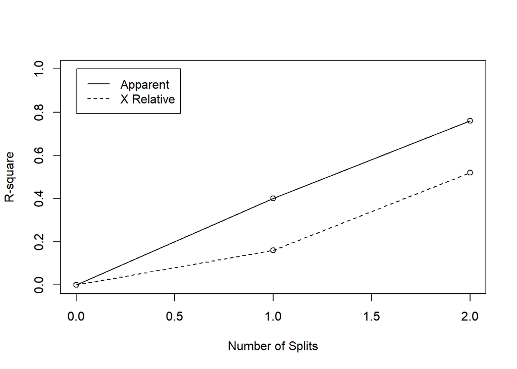

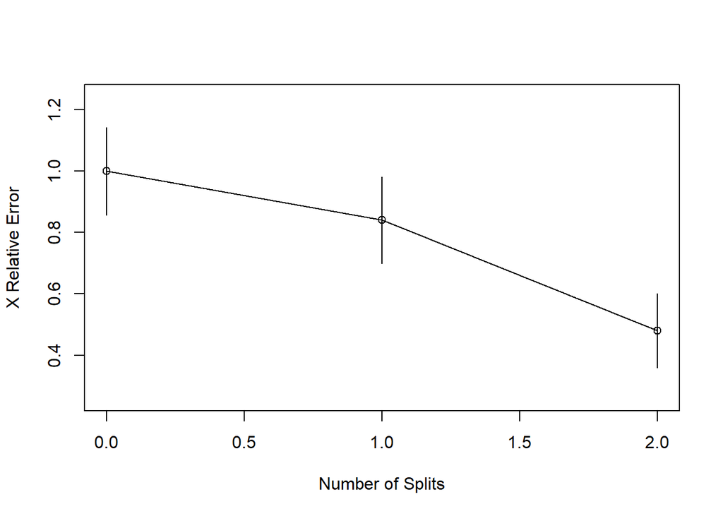

```r
#predict the test dataset using the model for train tree No. 1
predicted1= predict(train_tree1, test, type="class")
#plot number of splits
rsq.rpart(train_tree1)
```

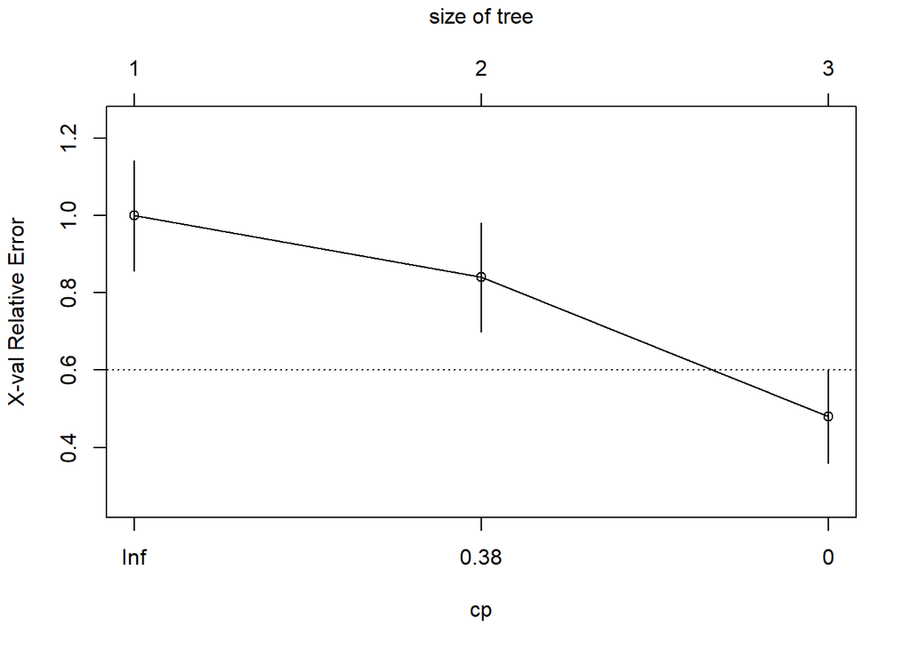

```r
plotcp(train_tree1)
```

[figure not shown]

```r
#plot the decision tree
fancyRpartPlot(train_tree1)
```

```r
#confusion matrix to find correct and incorrect predictions
table(Authorship=predicted1, true=test$Author)
```

```
##                     true
## Authorship           dispt hamil madis Madison_fed_43.txt
##   dispt                  1     0     1                  0
##   hamil                  0    25     0                  0
##   madis                  0     0     3                  1
##   Madison_fed_42.txt     0     0     0                  0
##   Madison_fed_44.txt     0     0     0                  0
##   Madison_fed_48.txt     0     0     0                  0
##   Madison_fed_58.txt     0     0     0                  0
##                     true
## Authorship           Madison_fed_45.txt Madison_fed_46.txt
##   dispt                               0                  1
##   hamil                               0                  0
##   madis                               1                  0
##   Madison_fed_42.txt                  0                  0
##   Madison_fed_44.txt                  0                  0
##   Madison_fed_48.txt                  0                  0
##   Madison_fed_58.txt                  0                  0
##                     true
## Authorship           Madison_fed_47.txt
##   dispt                               1
##   hamil                               0
##   madis                               0
##   Madison_fed_42.txt                  0
##   Madison_fed_44.txt                  0
##   Madison_fed_48.txt                  0
##   Madison_fed_58.txt                  0
```

```r
#Train Tree Model 2
train_tree2 <- rpart(Author ~ ., data = train, method="class", control=rpart.control(cp=0, minsplit = 2, maxdepth = 5))
summary(train_tree2)
```

```
## Call:
## rpart(formula = Author ~ ., data = train, method = "class", control = rpart.control(cp = 0,
##     minsplit = 2, maxdepth = 5))
##   n= 51
##
##     CP nsplit rel error xerror      xstd
## 1 0.40      0      1.00   1.00 0.1428011
## 2 0.36      1      0.60   1.00 0.1428011
## 3 0.04      2      0.24   0.44 0.1174901
## 4 0.00      8      0.00   0.52 0.1244911
##
## Variable importance
##     upon     jame  alexand     kind   matter    thing    union   branch
##       13       11       11        7        7        7        6        4
##   legisl     peac   attent    might hamilton   necess    shall      abl
##        4        4        4        4        3        2        2        2
##    great    clear confeder    adopt advantag     alon  appoint  assembl
##        2        1        1        1        1        1        1        1
##    avoid
##        1
##
## Node number 1: 51 observations,    complexity param=0.4
##   predicted class=hamil               expected loss=0.4901961  P(node) =1
##     class counts:    10    26    11     1     1     1     1
##    probabilities: 0.196 0.510 0.216 0.020 0.020 0.020 0.020
##   left son=2 (27 obs) right son=3 (24 obs)
##   Primary splits:
##       upon     < 0.0035 to the right, improve=15.907410, (0 missing)
##       jame     < 5e-04  to the left,  improve=13.379630, (0 missing)
##       alexand  < 5e-04  to the right, improve= 9.398111, (0 missing)
##       hamilton < 5e-04  to the right, improve= 9.398111, (0 missing)
##       kind     < 5e-04  to the right, improve= 6.268519, (0 missing)
##   Surrogate splits:
##       jame    < 5e-04  to the left,  agree=0.922, adj=0.833, (0 split)
##       kind    < 5e-04  to the right, agree=0.784, adj=0.542, (0 split)
##       matter  < 5e-04  to the right, agree=0.765, adj=0.500, (0 split)
##       thing   < 0.0015 to the right, agree=0.765, adj=0.500, (0 split)
##       alexand < 5e-04  to the right, agree=0.745, adj=0.458, (0 split)
##
## Node number 2: 27 observations,    complexity param=0.04
```

[output cut: 130 more lines]

```
##
## Node number 53: 1 observations
##   predicted class=Madison_fed_42.txt  expected loss=0  P(node) =0.01960784
##     class counts:     0     0     0     1     0     0     0
##    probabilities: 0.000 0.000 0.000 1.000 0.000 0.000 0.000
##
## Node number 54: 1 observations
##   predicted class=Madison_fed_48.txt  expected loss=0  P(node) =0.01960784
##     class counts:     0     0     0     0     0     1     0
##    probabilities: 0.000 0.000 0.000 0.000 0.000 1.000 0.000
##
## Node number 55: 1 observations
##   predicted class=Madison_fed_58.txt  expected loss=0  P(node) =0.01960784
##     class counts:     0     0     0     0     0     0     1
##    probabilities: 0.000 0.000 0.000 0.000 0.000 0.000 1.000
```

```
##
## Classification tree:
## rpart(formula = Author ~ ., data = train, method = "class", control = rpart.control(cp = 0,
##     minsplit = 2, maxdepth = 5))
##
## Variables actually used in tree construction:
## [1] abl     adopt   alexand great   union   upon
##
## Root node error: 25/51 = 0.4902
##
## n= 51
##
##     CP nsplit rel error xerror    xstd
## 1 0.40      0      1.00   1.00 0.14280
## 2 0.36      1      0.60   1.00 0.14280
## 3 0.04      2      0.24   0.44 0.11749
## 4 0.00      8      0.00   0.52 0.12449
```

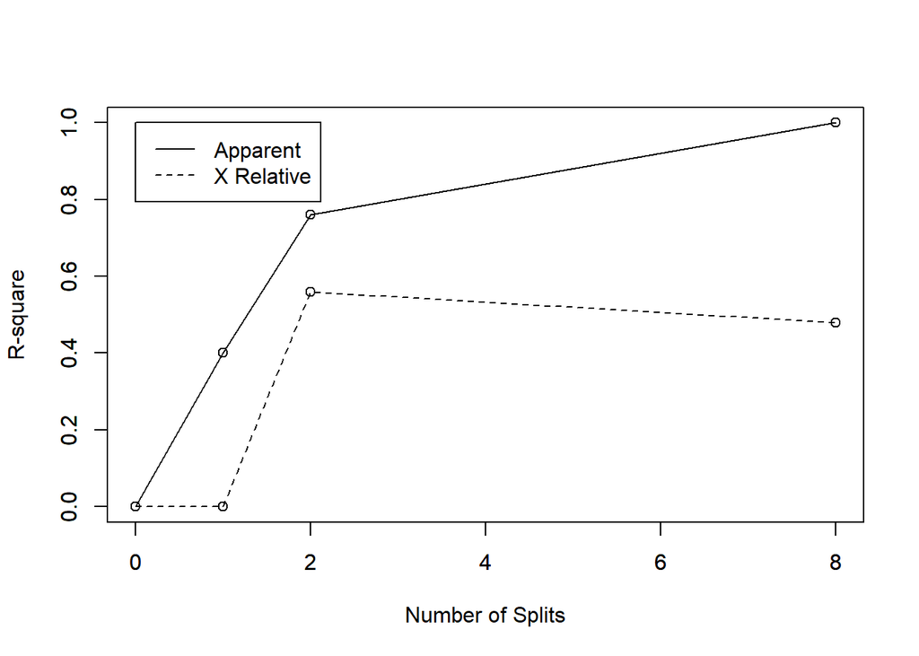

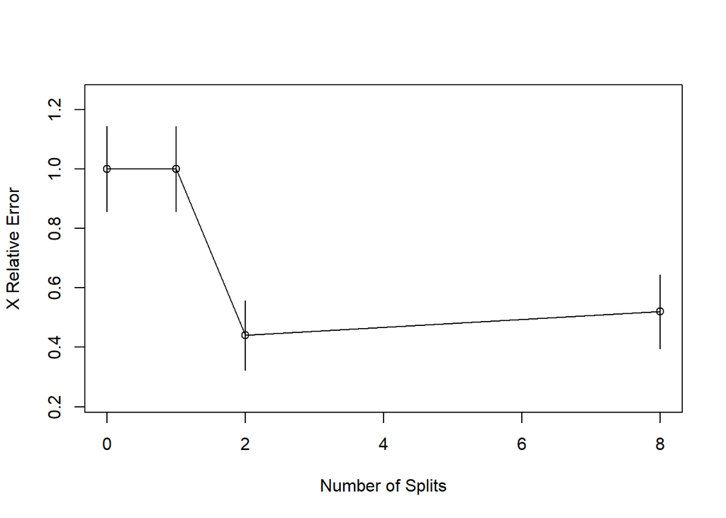

```r
#predict the test dataset using the model for train tree No. 1
predicted2= predict(train_tree2, test, type="class")
#plot number of splits
rsq.rpart(train_tree2)
```

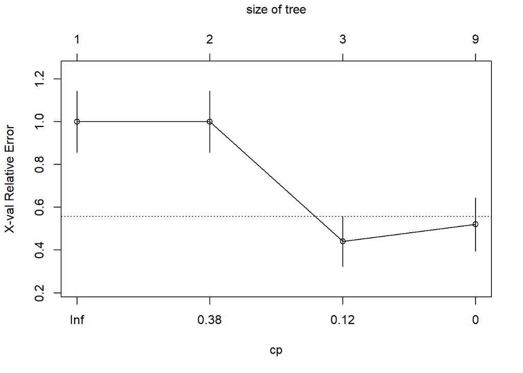

```r
plotcp(train_tree2)
```

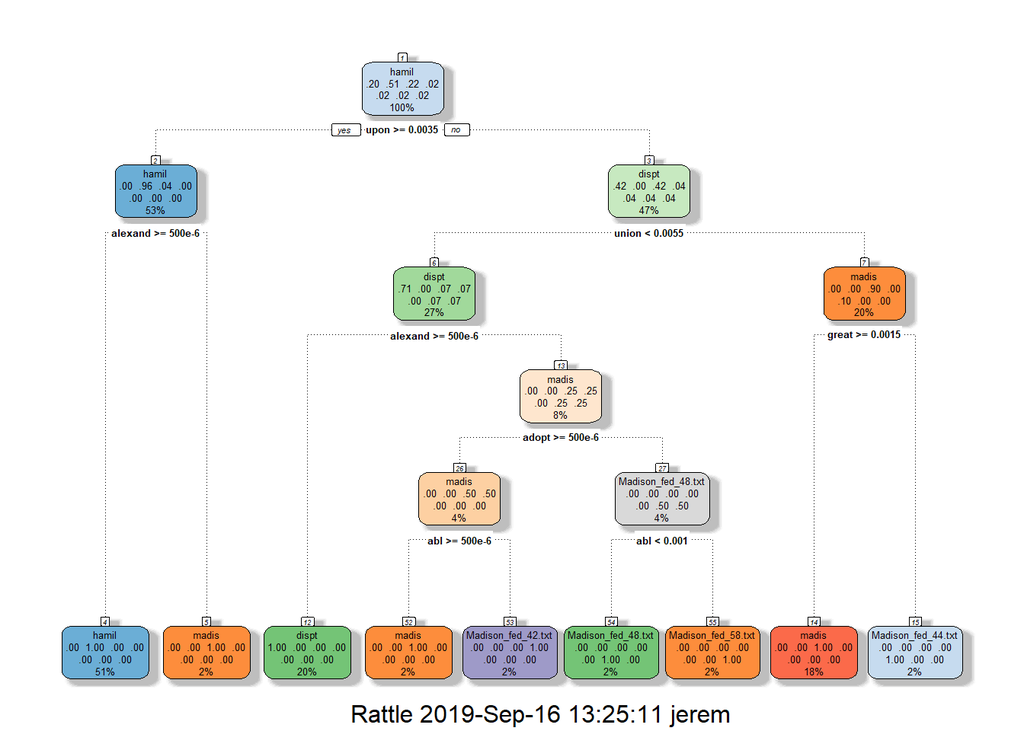

```r
#plot the decision tree
fancyRpartPlot(train_tree2)
```

```r
#confusion matrix to find correct and incorrect predictions
table(Authorship=predicted2, true=test$Author)
```

```
##                     true
## Authorship           dispt hamil madis Madison_fed_43.txt
##   dispt                  1     0     0                  0
##   hamil                  0    25     0                  0
##   madis                  0     0     2                  1
##   Madison_fed_42.txt     0     0     0                  0
##   Madison_fed_44.txt     0     0     1                  0
##   Madison_fed_48.txt     0     0     0                  0
##   Madison_fed_58.txt     0     0     1                  0
##                     true
## Authorship           Madison_fed_45.txt Madison_fed_46.txt
##   dispt                               0                  0
##   hamil                               0                  0
##   madis                               1                  0
##   Madison_fed_42.txt                  0                  0
##   Madison_fed_44.txt                  0                  0
##   Madison_fed_48.txt                  0                  0
##   Madison_fed_58.txt                  0                  1
##                     true
## Authorship           Madison_fed_47.txt
##   dispt                               0
##   hamil                               0
##   madis                               0
##   Madison_fed_42.txt                  1
##   Madison_fed_44.txt                  0
##   Madison_fed_48.txt                  0
##   Madison_fed_58.txt                  0
```